# MB5370 Module 04. Data Science in R 3

Ivanya Johnson

2024-09-09

# Workshop 3: Data Wrangling

## Load packages

Loading the tidyverse and ggplot2 packages. I set my preferences to use dplyr functions over others and loaded any other packages that come with ggplot and tidyverse.

```r
library(tidyverse)
library(conflicted)
library(dplyr)

conflicts_prefer(dplyr::filter) # Use to set preferences
```

```
## [conflicted] Will prefer dplyr::filter over any other package.
```

```r
conflicts_prefer(dplyr::lag) # Use to set preferences
```

```
## [conflicted] Will prefer dplyr::lag over any other package.
```

```r
library(ggthemes)

library(ggplot2)
```

## Tidy Data

There are many ways to display a given data set, but not every way is easy to use for analysis. The process of rearranging your data to a format more appropriate for analysis is the process of “tidying.”

### Load Tables

The following tables are set in the tidyverse package

```r
table1
```

```
## # A tibble: 6 × 4
##   country      year  cases population
##   <chr>       <dbl>  <dbl>      <dbl>
## 1 Afghanistan  1999    745   19987071
## 2 Afghanistan  2000   2666   20595360
## 3 Brazil       1999  37737  172006362
## 4 Brazil       2000  80488  174504898
## 5 China        1999 212258 1272915272
## 6 China        2000 213766 1280428583
```

```r
table2
```

```
## # A tibble: 12 × 4
##    country      year type            count
##    <chr>       <dbl> <chr>           <dbl>
##  1 Afghanistan  1999 cases             745
##  2 Afghanistan  1999 population   19987071
##  3 Afghanistan  2000 cases            2666
##  4 Afghanistan  2000 population   20595360
##  5 Brazil       1999 cases           37737
##  6 Brazil       1999 population  172006362
##  7 Brazil       2000 cases           80488
##  8 Brazil       2000 population  174504898
##  9 China        1999 cases          212258
## 10 China        1999 population 1272915272
## 11 China        2000 cases          213766
## 12 China        2000 population 1280428583
```

```r
table3
```

```
## # A tibble: 6 × 3
##   country      year rate
##   <chr>       <dbl> <chr>
## 1 Afghanistan  1999 745/19987071
## 2 Afghanistan  2000 2666/20595360
## 3 Brazil       1999 37737/172006362
## 4 Brazil       2000 80488/174504898
## 5 China        1999 212258/1272915272
## 6 China        2000 213766/1280428583
```

### Compute rate per 10,000

```r
table1 %>% # This symbol is known as a pipe. We will learn more about pipes later.
  mutate(rate = cases / population * 10000)
```

```
## # A tibble: 6 × 5
##   country      year  cases population  rate
##   <chr>       <dbl>  <dbl>      <dbl> <dbl>
## 1 Afghanistan  1999    745   19987071 0.373
## 2 Afghanistan  2000   2666   20595360 1.29
## 3 Brazil       1999  37737  172006362 2.19
## 4 Brazil       2000  80488  174504898 4.61
## 5 China        1999 212258 1272915272 1.67
## 6 China        2000 213766 1280428583 1.67
```

By using the mutate function, we have taken table1 and created a new column called ‘Rate’ that is cases / population * 10000

### Compute cases per year

```r
table1 %>%
  count(year, wt = cases)
```

```
## # A tibble: 2 × 2
##    year      n
##   <dbl>  <dbl>
## 1  1999 250740
## 2  2000 296920
```

Because of the structure of table1, we can call specific years and look at the TOTAL number of cases in each year.

### Visualize Changes Over Time

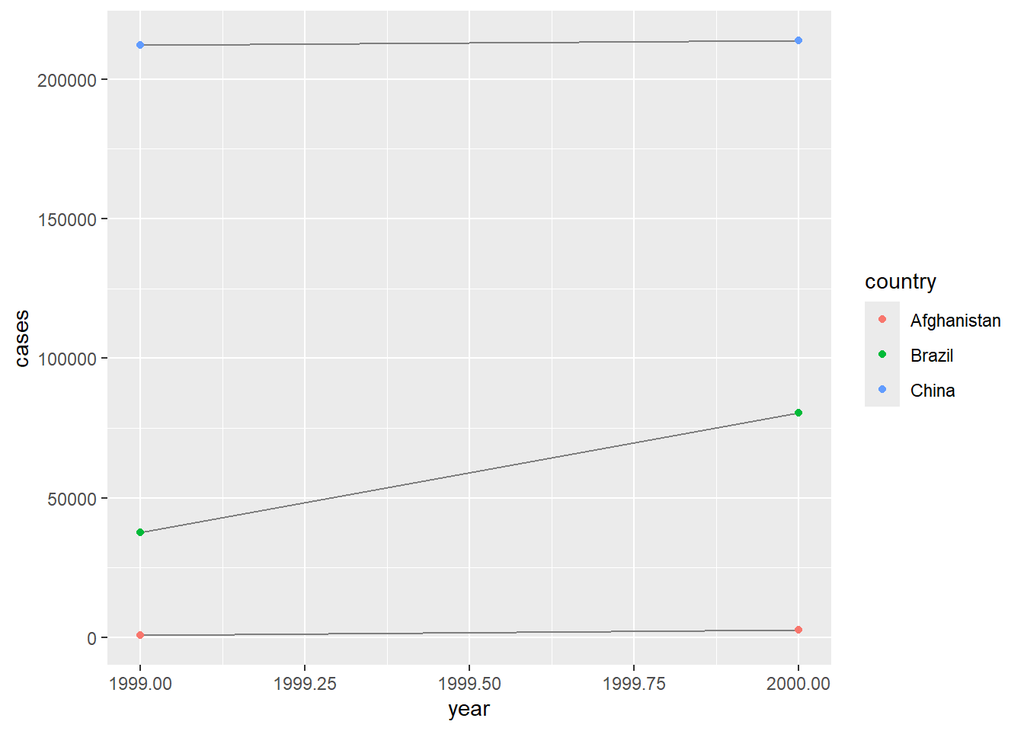

```r
ggplot(table1, aes(year, cases)) +
  geom_line(aes(group = country), color = "grey50") +
  geom_point(aes(color = country))
```

We can plot table1 in a nice graph to show cases per year per country. Each line represents a different country and the colored points at the end of each line verify which line corresponds to which country.

## Exercise 3

1. For each of the sample tables, describe what each observation and each column represents.

```r
table1
```

```
## # A tibble: 6 × 4
##   country      year  cases population
##   <chr>       <dbl>  <dbl>      <dbl>
## 1 Afghanistan  1999    745   19987071
## 2 Afghanistan  2000   2666   20595360
## 3 Brazil       1999  37737  172006362
## 4 Brazil       2000  80488  174504898
## 5 China        1999 212258 1272915272
## 6 China        2000 213766 1280428583
```

```r
table2
```

```
## # A tibble: 12 × 4
##    country      year type            count
##    <chr>       <dbl> <chr>           <dbl>
##  1 Afghanistan  1999 cases             745
##  2 Afghanistan  1999 population   19987071
##  3 Afghanistan  2000 cases            2666
##  4 Afghanistan  2000 population   20595360
##  5 Brazil       1999 cases           37737
##  6 Brazil       1999 population  172006362
##  7 Brazil       2000 cases           80488
##  8 Brazil       2000 population  174504898
##  9 China        1999 cases          212258
## 10 China        1999 population 1272915272
## 11 China        2000 cases          213766
## 12 China        2000 population 1280428583
```

```r
table3
```

```
## # A tibble: 6 × 3
##   country      year rate
##   <chr>       <dbl> <chr>
## 1 Afghanistan  1999 745/19987071
## 2 Afghanistan  2000 2666/20595360
## 3 Brazil       1999 37737/172006362
## 4 Brazil       2000 80488/174504898
## 5 China        1999 212258/1272915272
## 6 China        2000 213766/1280428583
```

Each of the three sample tables show the same data: cases of TB per country per year. In table 1, the columns are country, year, cases, and population. Table 2 columns are country, year, type, and count. Table 3 columns are country, year, and rate. Table 1 is tidy because it has split the total population from the cases count. Table 2 has a column labeled type because the corresponding count is either for a population or cases. Lastly, table 3’s column labeled rate shows the number of cases/population for each country in a given year, but not in the correct format.

2. Sketch out the processes you’d use to calculate the ‘rate’ for table2 and table3. You will need to perform four operations.
1. Extract the number of TB cases per country per year
   - For table 2 I would use pivot_wider to split the column type into two separate columns (cases and population).For table 3, use the separate function to separate the rate column into cases and population.
2. Extract the matching population per country per year
   - Once we have separate columns, I would then need to pivot longer by year to match the cases and population with each country by year.
3. Divide cases by population, and multiply by 1,000
   - Using the mutate function, set the new column title to rate and the equation would be cases / population * 1000 to get the rate of TB per country per year.
4. Store back in the appropriate place
   - Call the table and check the data to make sure it has performed the calculation and given the correct values for the new column. We need to use the unite function to tell R to read the values as numeric, not characters.

## Pivoting Data

### Lengthening Data

Pivoting data sets longer is the most common tidying issue. pivot_longer() makes data sets “longer” by *increasing the # of rows* and *decreasing the number of columns*. pivot_longer() splits the data set by column, and re-formats it into the tidy format of observations as rows, columns as variables, and values as cell entries.

Calling a data set in the tidyr package

```r
billboard
```

```
## # A tibble: 317 × 79
##    artist     track date.entered   wk1   wk2   wk3   wk4   wk5   wk6   wk7   wk8
##    <chr>      <chr> <date>       <dbl> <dbl> <dbl> <dbl> <dbl> <dbl> <dbl> <dbl>
##  1 2 Pac      Baby… 2000-02-26      87    82    72    77    87    94    99    NA
##  2 2Ge+her    The … 2000-09-02      91    87    92    NA    NA    NA    NA    NA
##  3 3 Doors D… Kryp… 2000-04-08      81    70    68    67    66    57    54    53
##  4 3 Doors D… Loser 2000-10-21      76    76    72    69    67    65    55    59
##  5 504 Boyz   Wobb… 2000-04-15      57    34    25    17    17    31    36    49
##  6 98^0       Give… 2000-08-19      51    39    34    26    26    19     2     2
##  7 A*Teens    Danc… 2000-07-08      97    97    96    95   100    NA    NA    NA
##  8 Aaliyah    I Do… 2000-01-29      84    62    51    41    38    35    35    38
##  9 Aaliyah    Try … 2000-03-18      59    53    38    28    21    18    16    14
## 10 Adams, Yo… Open… 2000-08-26      76    76    74    69    68    67    61    58
## # ℹ 307 more rows
## # ℹ 68 more variables: wk9 <dbl>, wk10 <dbl>, wk11 <dbl>, wk12 <dbl>,
## #   wk13 <dbl>, wk14 <dbl>, wk15 <dbl>, wk16 <dbl>, wk17 <dbl>, wk18 <dbl>,
## #   wk19 <dbl>, wk20 <dbl>, wk21 <dbl>, wk22 <dbl>, wk23 <dbl>, wk24 <dbl>,
## #   wk25 <dbl>, wk26 <dbl>, wk27 <dbl>, wk28 <dbl>, wk29 <dbl>, wk30 <dbl>,
## #   wk31 <dbl>, wk32 <dbl>, wk33 <dbl>, wk34 <dbl>, wk35 <dbl>, wk36 <dbl>,
## #   wk37 <dbl>, wk38 <dbl>, wk39 <dbl>, wk40 <dbl>, wk41 <dbl>, wk42 <dbl>, …
```

Using the pivot_longer() function to take all the columns that start with ‘wk’ and put them into one column labeled “week”.

```r
billboard |>
  pivot_longer(
    cols = starts_with("wk"),
    names_to = "week",
    values_to = "rank"
  )
```

```
## # A tibble: 24,092 × 5
##    artist track                   date.entered week   rank
##    <chr>  <chr>                   <date>       <chr> <dbl>
##  1 2 Pac  Baby Don't Cry (Keep... 2000-02-26   wk1      87
##  2 2 Pac  Baby Don't Cry (Keep... 2000-02-26   wk2      82
##  3 2 Pac  Baby Don't Cry (Keep... 2000-02-26   wk3      72
##  4 2 Pac  Baby Don't Cry (Keep... 2000-02-26   wk4      77
##  5 2 Pac  Baby Don't Cry (Keep... 2000-02-26   wk5      87
##  6 2 Pac  Baby Don't Cry (Keep... 2000-02-26   wk6      94
##  7 2 Pac  Baby Don't Cry (Keep... 2000-02-26   wk7      99
##  8 2 Pac  Baby Don't Cry (Keep... 2000-02-26   wk8      NA
##  9 2 Pac  Baby Don't Cry (Keep... 2000-02-26   wk9      NA
## 10 2 Pac  Baby Don't Cry (Keep... 2000-02-26   wk10     NA
## # ℹ 24,082 more rows
```

Further cleaning of the data by removing NA values

```r
billboard |>
  pivot_longer(
    cols = starts_with("wk"),
    names_to = "week",
    values_to = "rank",
    values_drop_na = TRUE
  ) # This is used to drop any NA values
```

```
## # A tibble: 5,307 × 5
##    artist  track                   date.entered week   rank
##    <chr>   <chr>                   <date>       <chr> <dbl>
##  1 2 Pac   Baby Don't Cry (Keep... 2000-02-26   wk1      87
##  2 2 Pac   Baby Don't Cry (Keep... 2000-02-26   wk2      82
##  3 2 Pac   Baby Don't Cry (Keep... 2000-02-26   wk3      72
##  4 2 Pac   Baby Don't Cry (Keep... 2000-02-26   wk4      77
##  5 2 Pac   Baby Don't Cry (Keep... 2000-02-26   wk5      87
##  6 2 Pac   Baby Don't Cry (Keep... 2000-02-26   wk6      94
##  7 2 Pac   Baby Don't Cry (Keep... 2000-02-26   wk7      99
##  8 2Ge+her The Hardest Part Of ... 2000-09-02   wk1      91
##  9 2Ge+her The Hardest Part Of ... 2000-09-02   wk2      87
## 10 2Ge+her The Hardest Part Of ... 2000-09-02   wk3      92
## # ℹ 5,297 more rows
```

#### Pivoting Longer

Created a data set called ‘df’ with three variables and their associated values

New tidy data set with three variables: 1. id (already exists) 2. measurement (column names) 3. value (cell values)

```r
df <- tribble(
  ~id, ~bp1, ~bp2,
  #--|-----|------
  "A", 100, 120,
  "B", 140, 115,
  "C", 120, 125
)
```

Tidying the new tibble to take the columns ‘bpa’ and ‘bp2’ and put them into one column called “measurement”

```r
df |> # This is another symbol for pipes
  pivot_longer(
    cols = bp1:bp2,
    names_to = "measurement",
    values_to = "value"
  )
```

```
## # A tibble: 6 × 3
##   id    measurement value
##   <chr> <chr>       <dbl>
## 1 A     bp1           100
## 2 A     bp2           120
## 3 B     bp1           140
## 4 B     bp2           115
## 5 C     bp1           120
## 6 C     bp2           125
```

### Widening Data

Widening a data set is the opposite of lengthening and we do so using the pivot_wider() function. pivot_wider() allows us to handle an observation if it’s scattered across *multiple rows*.

Calling a data set in the tidyr package

```r
cms_patient_experience
```

```
## # A tibble: 500 × 5
##    org_pac_id org_nm                           measure_cd measure_title prf_rate
##    <chr>      <chr>                            <chr>      <chr>            <dbl>
##  1 0446157747 USC CARE MEDICAL GROUP INC       CAHPS_GRP… CAHPS for MI…       63
##  2 0446157747 USC CARE MEDICAL GROUP INC       CAHPS_GRP… CAHPS for MI…       87
##  3 0446157747 USC CARE MEDICAL GROUP INC       CAHPS_GRP… CAHPS for MI…       86
##  4 0446157747 USC CARE MEDICAL GROUP INC       CAHPS_GRP… CAHPS for MI…       57
##  5 0446157747 USC CARE MEDICAL GROUP INC       CAHPS_GRP… CAHPS for MI…       85
##  6 0446157747 USC CARE MEDICAL GROUP INC       CAHPS_GRP… CAHPS for MI…       24
##  7 0446162697 ASSOCIATION OF UNIVERSITY PHYSI… CAHPS_GRP… CAHPS for MI…       59
##  8 0446162697 ASSOCIATION OF UNIVERSITY PHYSI… CAHPS_GRP… CAHPS for MI…       85
##  9 0446162697 ASSOCIATION OF UNIVERSITY PHYSI… CAHPS_GRP… CAHPS for MI…       83
## 10 0446162697 ASSOCIATION OF UNIVERSITY PHYSI… CAHPS_GRP… CAHPS for MI…       63
## # ℹ 490 more rows
```

Instead of choosing new column names, we need to provide the existing columns that define the values and the column name.

```r
cms_patient_experience |>
  distinct(measure_cd, measure_title)
```

```
## # A tibble: 6 × 2
##   measure_cd   measure_title
##   <chr>        <chr>
## 1 CAHPS_GRP_1  CAHPS for MIPS SSM: Getting Timely Care, Appointments, and Infor…
## 2 CAHPS_GRP_2  CAHPS for MIPS SSM: How Well Providers Communicate
## 3 CAHPS_GRP_3  CAHPS for MIPS SSM: Patient's Rating of Provider
## 4 CAHPS_GRP_5  CAHPS for MIPS SSM: Health Promotion and Education
## 5 CAHPS_GRP_8  CAHPS for MIPS SSM: Courteous and Helpful Office Staff
## 6 CAHPS_GRP_12 CAHPS for MIPS SSM: Stewardship of Patient Resources
```

Tibble doesn’t look right because we need to also tell the pivot_wider() which column or columns have values that uniquely identify each row.

```r
cms_patient_experience |>
  pivot_wider(
    names_from = measure_cd,
    values_from = prf_rate
  )
```

```
## # A tibble: 500 × 9
##    org_pac_id org_nm           measure_title CAHPS_GRP_1 CAHPS_GRP_2 CAHPS_GRP_3
##    <chr>      <chr>            <chr>               <dbl>       <dbl>       <dbl>
##  1 0446157747 USC CARE MEDICA… CAHPS for MI…          63          NA          NA
##  2 0446157747 USC CARE MEDICA… CAHPS for MI…          NA          87          NA
##  3 0446157747 USC CARE MEDICA… CAHPS for MI…          NA          NA          86
##  4 0446157747 USC CARE MEDICA… CAHPS for MI…          NA          NA          NA
##  5 0446157747 USC CARE MEDICA… CAHPS for MI…          NA          NA          NA
##  6 0446157747 USC CARE MEDICA… CAHPS for MI…          NA          NA          NA
##  7 0446162697 ASSOCIATION OF … CAHPS for MI…          59          NA          NA
##  8 0446162697 ASSOCIATION OF … CAHPS for MI…          NA          85          NA
##  9 0446162697 ASSOCIATION OF … CAHPS for MI…          NA          NA          83
## 10 0446162697 ASSOCIATION OF … CAHPS for MI…          NA          NA          NA
## # ℹ 490 more rows
## # ℹ 3 more variables: CAHPS_GRP_5 <dbl>, CAHPS_GRP_8 <dbl>, CAHPS_GRP_12 <dbl>
```

Final product

```r
cms_patient_experience |>
  pivot_wider(
    id_cols = starts_with("org"),
    names_from = measure_cd,
    values_from = prf_rate
  )
```

```
## # A tibble: 95 × 8
##    org_pac_id org_nm CAHPS_GRP_1 CAHPS_GRP_2 CAHPS_GRP_3 CAHPS_GRP_5 CAHPS_GRP_8
##    <chr>      <chr>        <dbl>       <dbl>       <dbl>       <dbl>       <dbl>
##  1 0446157747 USC C…          63          87          86          57          85
##  2 0446162697 ASSOC…          59          85          83          63          88
##  3 0547164295 BEAVE…          49          NA          75          44          73
##  4 0749333730 CAPE …          67          84          85          65          82
##  5 0840104360 ALLIA…          66          87          87          64          87
##  6 0840109864 REX H…          73          87          84          67          91
##  7 0840513552 SCL H…          58          83          76          58          78
##  8 0941545784 GRITM…          46          86          81          54          NA
##  9 1052612785 COMMU…          65          84          80          58          87
## 10 1254237779 OUR L…          61          NA          NA          65          NA
## # ℹ 85 more rows
## # ℹ 1 more variable: CAHPS_GRP_12 <dbl>
```

#### Pivoting Wider

New tidy data set with three columns and five rows

```r
df <- tribble(
  ~id, ~measurement, ~value,
  #--|------------|---------
  "A",    "bp1",      100,
  "B",    "bp1",      140,
  "B",    "bp2",      115,
  "A",    "bp2",      120,
  "A",    "bp3",      105
)
```

Use the pivot_wider function to condense the id column and expand each value in the measurements column to their own column.

```r
df |>
  pivot_wider(
    names_from = measurement,
    values_from = value
  )
```

```
## # A tibble: 2 × 4
##   id      bp1   bp2   bp3
##   <chr> <dbl> <dbl> <dbl>
## 1 A       100   120   105
## 2 B       140   115    NA
```

Pull the values associated with measurement that aren’t going into the new names or values.

```r
df |>
  distinct(measurement) |>
  pull()
```

```
## [1] "bp1" "bp2" "bp3"
```

Select the columns to remove and just gives us the ‘id’ column

```r
df |>
  select(-measurement, -value) |>
  distinct()
```

```
## # A tibble: 2 × 1
##   id
##   <chr>
## 1 A
## 2 B
```

This fills all of the missing values with “NA” using the data in the input.

```r
df |>
  select(-measurement, -value) |>
  distinct() |>
  mutate(x = NA, y = NA, z = NA)
```

```
## # A tibble: 2 × 4
##   id    x     y     z
##   <chr> <lgl> <lgl> <lgl>
## 1 A     NA    NA    NA
## 2 B     NA    NA    NA
```

## Exercise 4

1. Why are pivot_longer() and pivot_wider() not perfectly symmetrical? Carefully consider the following example.

```r
stocks <- tibble(
  year   = c(2015, 2015, 2016, 2016),
  half  = c(   1,    2,     1,    2),
  return = c(1.88, 0.59, 0.92, 0.17)
)

stocks %>%
  pivot_wider(names_from = year, values_from = return) %>%
  pivot_longer(`2015`:`2016`, names_to = "year", values_to = "return")
```

```
## # A tibble: 4 × 3
##    half year  return
##   <dbl> <chr>  <dbl>
## 1     1 2015    1.88
## 2     1 2016    0.92
## 3     2 2015    0.59
## 4     2 2016    0.17
```

2. Why does this code fail? Note: I needed to hashtag the code out to knit this file.

```r
# table4a %>%
#  pivot_longer(c(1999, 2000), names_to = "year", values_to = "cases")

# Error: Can't select columns past the end. Locations 1999 and 2000 don't exist. There are only 3 columns. To select the columns 1999 and 200, you need (``) or provide the information as a string.
```

3. Consider the sample tibble below. Do you need to make it wider or longer? What are the variables?

```r
preg <- tribble(
  ~pregnant, ~male, ~female,
  "yes",     NA,    10,
  "no",      20,    12
)

# Use pivot_longer to create variables sex (male, female), pregnant (yes, no), and count.
```

## Separating / Uniting Data Tables

In this section, the example table (table 3) has a column (rate) that contains two variables (cases and population). To address this issue, we can use the separate() function, which separates one column into multiple columns.

Load table3, provided by tidyverse

```r
table3
```

```
## # A tibble: 6 × 3
##   country      year rate
##   <chr>       <dbl> <chr>
## 1 Afghanistan  1999 745/19987071
## 2 Afghanistan  2000 2666/20595360
## 3 Brazil       1999 37737/172006362
## 4 Brazil       2000 80488/174504898
## 5 China        1999 212258/1272915272
## 6 China        2000 213766/1280428583
```

Separate the ‘rate’ column

```r
table3 %>%
  separate(rate, into = c("cases", "population"))
```

```
## # A tibble: 6 × 4
##   country      year cases  population
##   <chr>       <dbl> <chr>  <chr>
## 1 Afghanistan  1999 745    19987071
## 2 Afghanistan  2000 2666   20595360
## 3 Brazil       1999 37737  172006362
## 4 Brazil       2000 80488  174504898
## 5 China        1999 212258 1272915272
## 6 China        2000 213766 1280428583
```

By default, separate() will split values wherever it sees a non-alphanumeric character (i.e. a character that isn’t a number or letter). If you wish to use a specific character to separate a column, you can pass the character to the sep argument of separate().

You can set where you want the separation to occur

```r
table3 %>%
  separate(rate, into = c("cases", "population"), sep = "/")
```

```
## # A tibble: 6 × 4
##   country      year cases  population
##   <chr>       <dbl> <chr>  <chr>
## 1 Afghanistan  1999 745    19987071
## 2 Afghanistan  2000 2666   20595360
## 3 Brazil       1999 37737  172006362
## 4 Brazil       2000 80488  174504898
## 5 China        1999 212258 1272915272
## 6 China        2000 213766 1280428583
```

As a default, separate() labeled ‘cases’ and ‘population’ as character types. But the values are numeric. We want to ask separate() to convert them to better types using convert = TRUE.

Convert the label to integers

```r
table3 %>%
  separate(rate, into = c("cases", "population"), convert = TRUE)
```

```
## # A tibble: 6 × 4
##   country      year  cases population
##   <chr>       <dbl>  <int>      <int>
## 1 Afghanistan  1999    745   19987071
## 2 Afghanistan  2000   2666   20595360
## 3 Brazil       1999  37737  172006362
## 4 Brazil       2000  80488  174504898
## 5 China        1999 212258 1272915272
## 6 China        2000 213766 1280428583
```

Extra practice with the separate function by separating the column ‘year’ into century and year.

```r
table3 %>%
  separate(year, into = c("century", "year"), convert = TRUE, sep = 2)
```

```
## # A tibble: 6 × 4
##   country     century  year rate
##   <chr>         <int> <int> <chr>
## 1 Afghanistan      19    99 745/19987071
## 2 Afghanistan      20     0 2666/20595360
## 3 Brazil           19    99 37737/172006362
## 4 Brazil           20     0 80488/174504898
## 5 China            19    99 212258/1272915272
## 6 China            20     0 213766/1280428583
```

### Using Unite

The unite() function takes the values within two columns and pushes them together to form one new column.

Load new table (table5) provided by tidyverse

```r
table5
```

```
## # A tibble: 6 × 4
##   country     century year  rate
##   <chr>       <chr>   <chr> <chr>
## 1 Afghanistan 19      99    745/19987071
## 2 Afghanistan 20      00    2666/20595360
## 3 Brazil      19      99    37737/172006362
## 4 Brazil      20      00    80488/174504898
## 5 China       19      99    212258/1272915272
## 6 China       20      00    213766/1280428583
```

Unite the split columns of century and year, back to one column labeled new.

```r
table5 %>%
  unite(new, century, year, sep = "")
```

```
## # A tibble: 6 × 3
##   country     new   rate
##   <chr>       <chr> <chr>
## 1 Afghanistan 1999  745/19987071
## 2 Afghanistan 2000  2666/20595360
## 3 Brazil      1999  37737/172006362
## 4 Brazil      2000  80488/174504898
## 5 China       1999  212258/1272915272
## 6 China       2000  213766/1280428583
```